# GAM and NN for Classification in R

Zifeng Zhao

week 05 session 01

In this lab, we will practice implementing Generalized Additive Model (GAM) and Neural Network (NN) in `R`.

## 1. Data Preparation

Let’s read in the data stored in `PersonalLoan.csv` and further do a 80%-20% training-test split from the very beginning. We use the `set.seed()` function in `R` to control the randomness of the training-test split.

```r
rm(list=ls())
set.seed(7)
total_data <- read.csv("./PersonalLoan.csv", header=T, stringsAsFactors=T)
total_obs <- dim(total_data)[1]
## Data Partition: Training v.s. Test split
train_data_indices <- sample(1:total_obs, 0.8*total_obs)
train_data <- total_data[train_data_indices,]
test_data <- total_data[-train_data_indices,]
```

We first reproduce the data visualization in the slides.

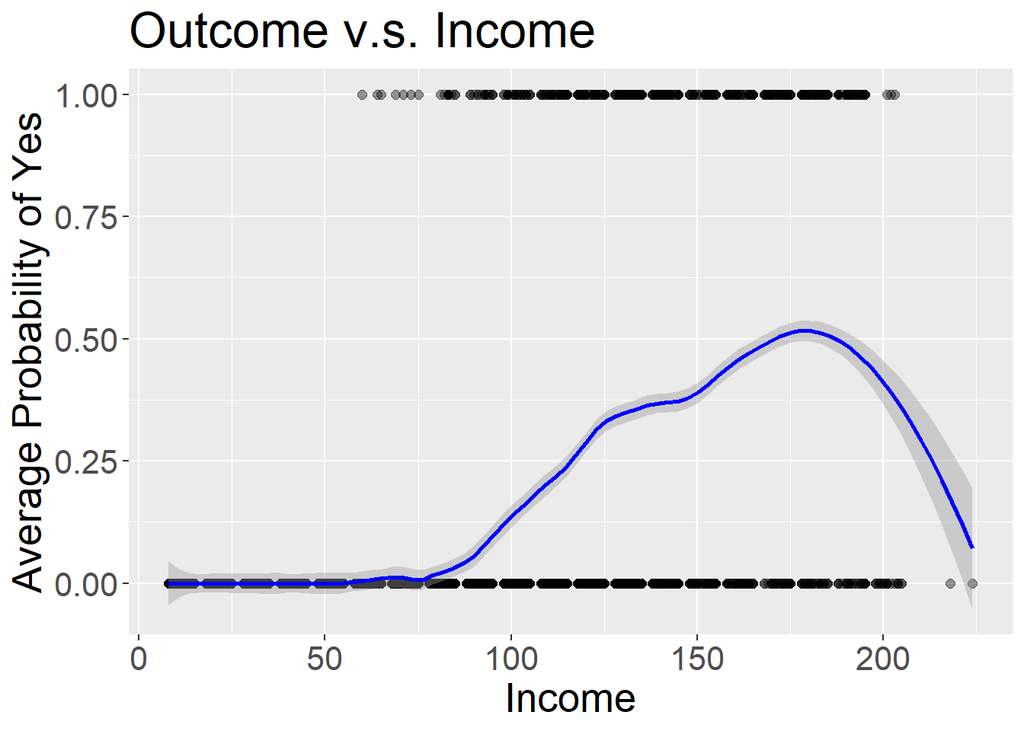

```r
library(ggplot2)
library(dplyr)
total_data$Dummy_Outcome <- as.numeric(total_data$Outcome=='Yes')

total_data %>%
  ggplot(aes(Income, Dummy_Outcome))+geom_point(size=2, alpha=0.4)+
  stat_smooth(method="loess", colour="blue", span=0.22, se=T, level=0.9)+
  xlab("Income")+
  ylab("Average Probability of Yes")+
  ggtitle('Outcome v.s. Income')+
  theme(text=element_text(size=20))
```

## 2. Logistic Regression

We first build a logistic regression model for the dependent variable `Outcome` with all predictors `Age+Experience+Income+Family+CCAvg+Education+Mortgage+CD_Account+Online+CreditCard` based on the **training** data using the function `glm()` and name it `lm_full`.

```r
## lm1 will regress on the non-reference level outcome!
lm_full <- glm(Outcome~Age+Experience+Income+Family+CCAvg+Education+Mortgage+CD_Account+Online+CreditCard,
               family='binomial', data=train_data)
lm_bwd <- step(lm_full, direction='backward', k=log(nrow(train_data)))
```

```
## Start:  AIC=1029.31
## Outcome ~ Age + Experience + Income + Family + CCAvg + Education +
##     Mortgage + CD_Account + Online + CreditCard
##
##              Df Deviance    AIC
## - Age         1   929.79 1021.0
## - Experience  1   929.84 1021.1
## - Mortgage    1   931.08 1022.3
## <none>            929.78 1029.3
## - CCAvg       1   943.64 1034.9
## - CreditCard  1   949.07 1040.3
## - Online      1   952.25 1043.5
## - Family      1   993.12 1084.4
## - CD_Account  1  1049.73 1141.0
## - Education   2  1262.22 1345.2
## - Income      1  1561.97 1653.2
##
## Step:  AIC=1021.02
## Outcome ~ Experience + Income + Family + CCAvg + Education +
##     Mortgage + CD_Account + Online + CreditCard
##
##              Df Deviance    AIC
## - Mortgage    1   931.09 1014.0
## - Experience  1   932.22 1015.2
## <none>            929.79 1021.0
## - CCAvg       1   943.65 1026.6
## - CreditCard  1   949.08 1032.0
## - Online      1   952.25 1035.2
## - Family      1   993.12 1076.1
## - CD_Account  1  1049.87 1132.8
## - Education   2  1274.00 1348.6
## - Income      1  1568.08 1651.0
##
## Step:  AIC=1014.03
## Outcome ~ Experience + Income + Family + CCAvg + Education +
##     CD_Account + Online + CreditCard
##
##              Df Deviance    AIC
## - Experience  1   933.41 1008.1
## <none>            931.09 1014.0
## - CCAvg       1   944.24 1018.9
## - CreditCard  1   950.84 1025.5
## - Online      1   953.62 1028.3
## - Family      1   995.29 1069.9
## - CD_Account  1  1052.01 1126.7
## - Education   2  1274.20 1340.5
## - Income      1  1594.29 1668.9
##
## Step:  AIC=1008.06
## Outcome ~ Income + Family + CCAvg + Education + CD_Account +
##     Online + CreditCard
##
##              Df Deviance    AIC
## <none>            933.41 1008.1
## - CCAvg       1   945.71 1012.1
## - CreditCard  1   953.30 1019.6
## - Online      1   955.64 1022.0
## - Family      1   996.32 1062.7
## - CD_Account  1  1055.88 1122.2
## - Education   2  1277.57 1335.6
## - Income      1  1594.63 1661.0
```

Let’s evaluate the prediction performance of `lm_full` and `lm_bwd` on the test data. We first use the `confusionMatrix()` function in the R package `caret` to automatically generate the error metrics such as accuracy, sensitivity and specificity.

```r
library(caret)
# Model deployment
lm_full_pred <- predict(lm_full, newdata=test_data, type='response')
lm_bwd_pred <- predict(lm_bwd, newdata = test_data, type = 'response')

# Test data error
lm_full_acc <- confusionMatrix(factor(ifelse(lm_full_pred>0.5, 'Yes', 'No')), test_data$Outcome, positive='Yes')


lm_bwd_pred_class <- factor(ifelse(lm_full_pred>0.5, 'Yes', 'No'))
lm_bwd_acc <- confusionMatrix(lm_bwd_pred_class, test_data$Outcome, positive='Yes')
```

We further use the `lift()` and `xyplot()` function in the R package `caret` to automatically generate the lift chart.

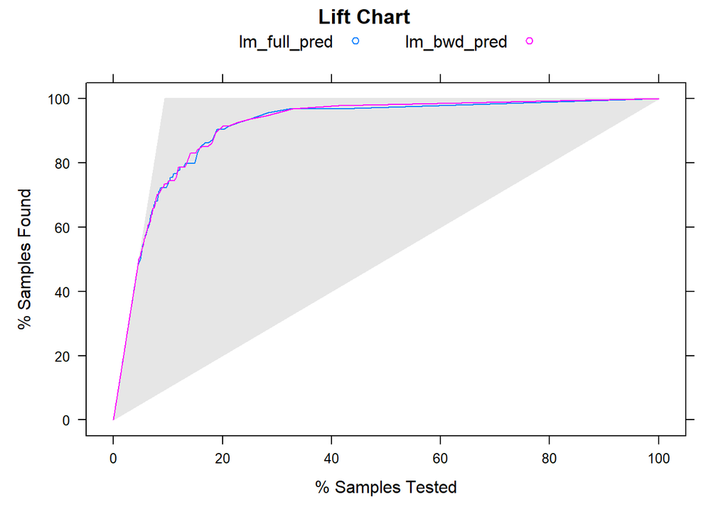

```r
## Lift chart
lift_chart <- lift(test_data$Outcome~lm_full_pred+lm_bwd_pred, class='Yes', cuts=100)
xyplot(lift_chart, auto.key=list(columns=2), main='Lift Chart')
```

## 3. Generalized Additive Model

We now build a GAM with all predictors to capture potential nonlinear relationship. We specify splines with degree-of-freedom=4 for all numerical predictors, including `Age`, `Experience`, `Income`, `Family`, `CCAvg` and `Mortgage`, and we store the model in `gam1`. We can use `plot()` function to visualize the estimated coefficients and splines for each predictor. Note that we can still interpret the estimated model `gam1` due to the additivity of GAM.

```r
library(gam)
```

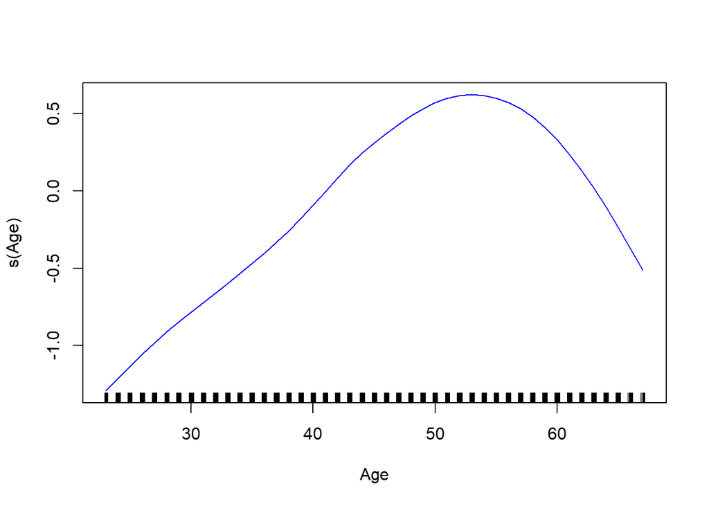

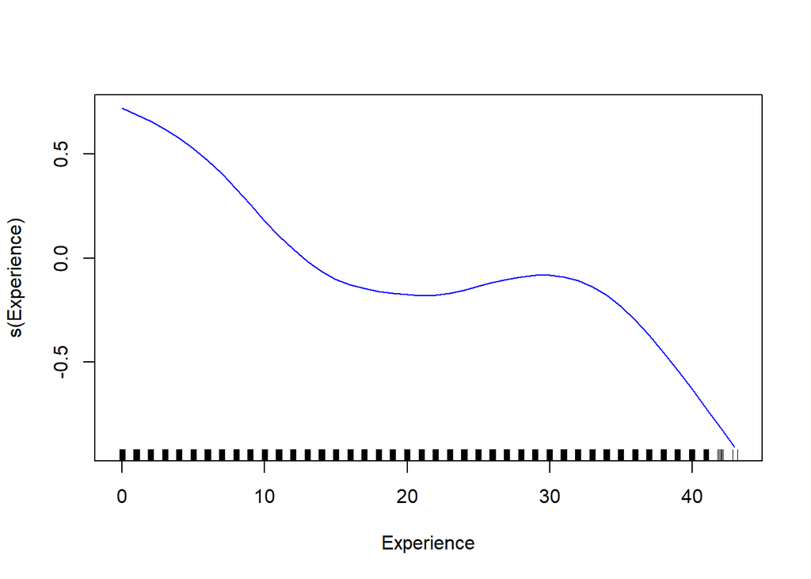

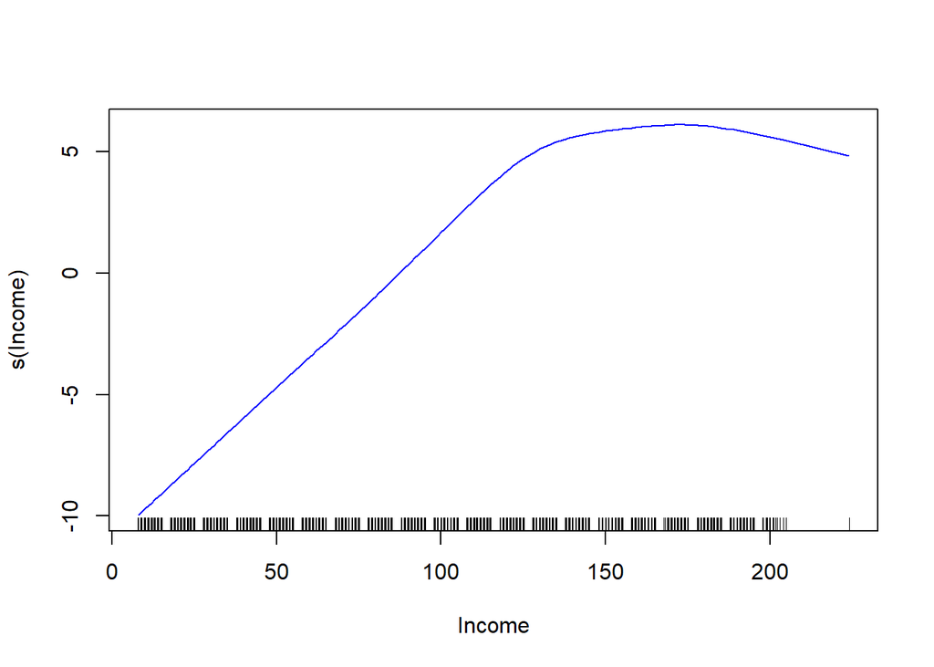

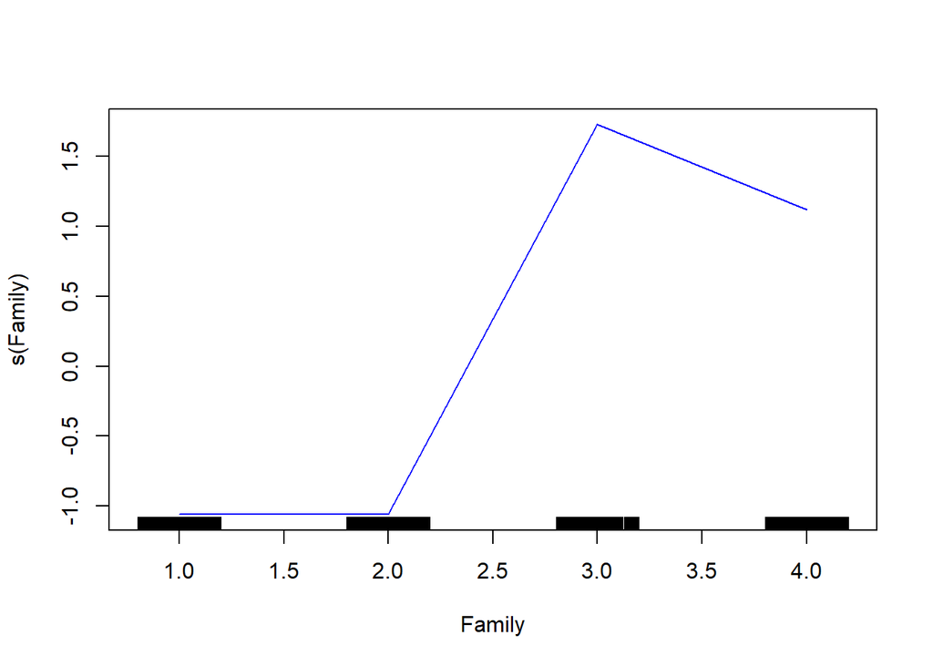

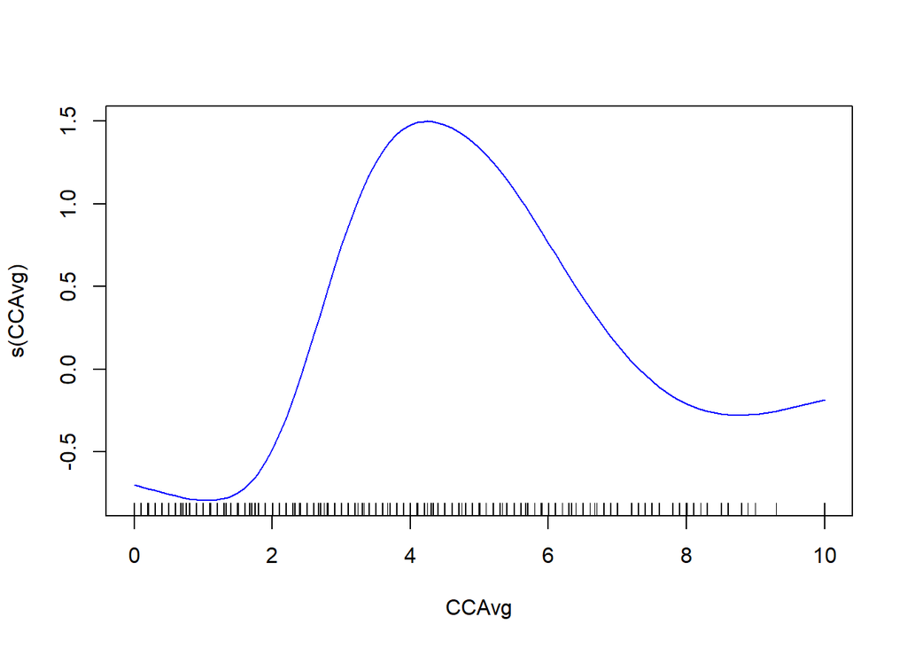

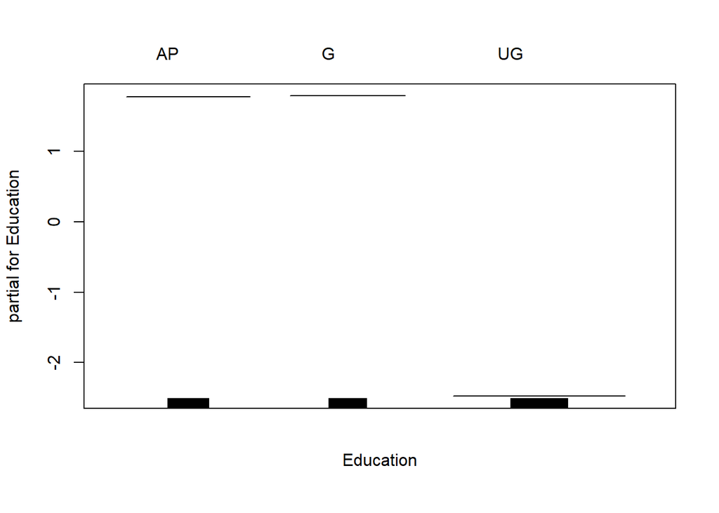

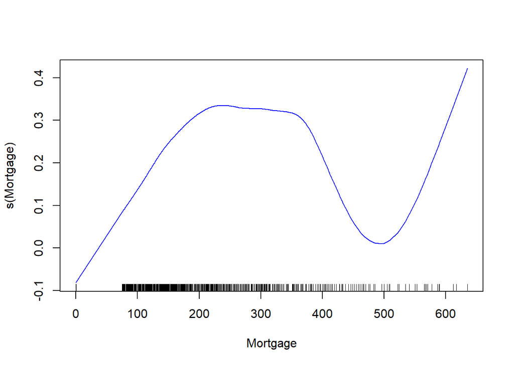

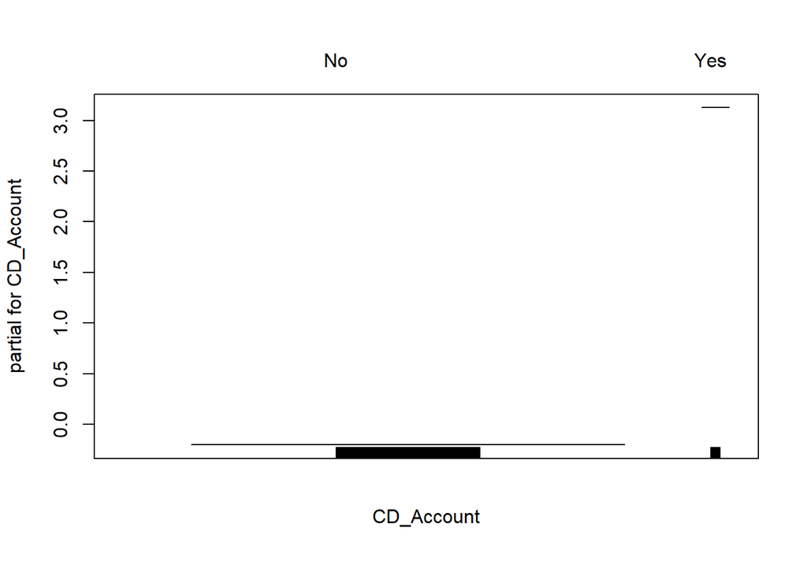

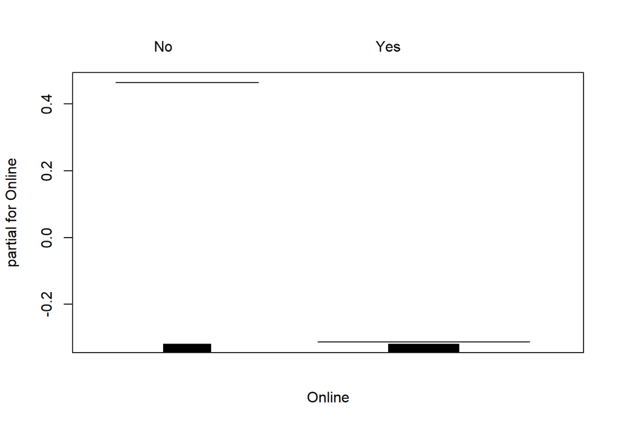

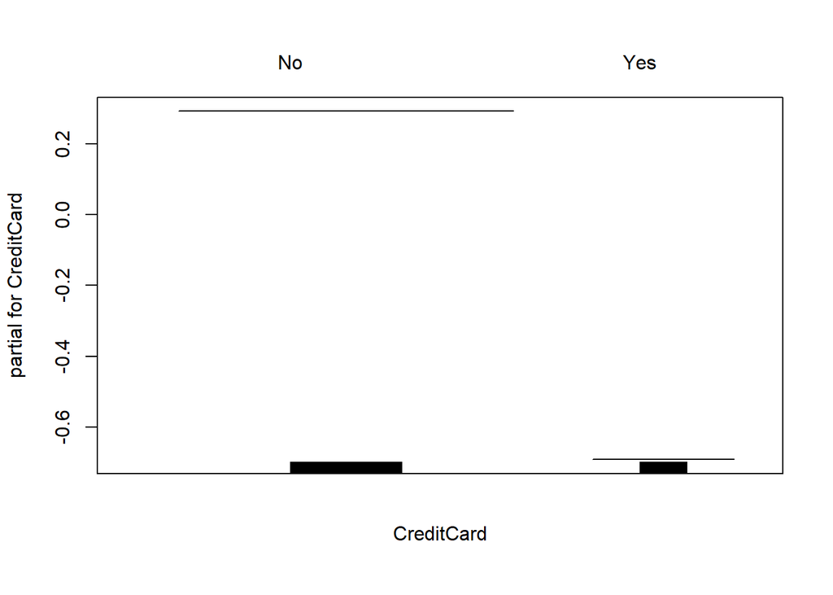

```r
## Fit a GAM
gam1 <- gam(Outcome~s(Age)+s(Experience)+s(Income)+s(Family)+s(CCAvg)+Education+s(Mortgage)+CD_Account+Online+CreditCard, family='binomial', data=train_data)
plot(gam1, col='blue')
```

```r
## Model evaluation on Test data
gam1_pred <- predict(gam1, newdata=test_data, type='response')
gam1_acc <- confusionMatrix(factor(ifelse(gam1_pred>0.5, 'Yes', 'No')), test_data$Outcome, positive='Yes')
print(gam1_acc)
```

```
## Confusion Matrix and Statistics
##
##           Reference
## Prediction  No Yes
##        No  898  16
##        Yes   8  78
##
##                Accuracy : 0.976
##                  95% CI : (0.9645, 0.9846)
##     No Information Rate : 0.906
##     P-Value [Acc > NIR] : <2e-16
##
##                   Kappa : 0.8535
##
##  Mcnemar's Test P-Value : 0.153
##
##             Sensitivity : 0.8298
##             Specificity : 0.9912
##          Pos Pred Value : 0.9070
##          Neg Pred Value : 0.9825
##              Prevalence : 0.0940
##          Detection Rate : 0.0780
##    Detection Prevalence : 0.0860
##       Balanced Accuracy : 0.9105
##
##        'Positive' Class : Yes
##
```

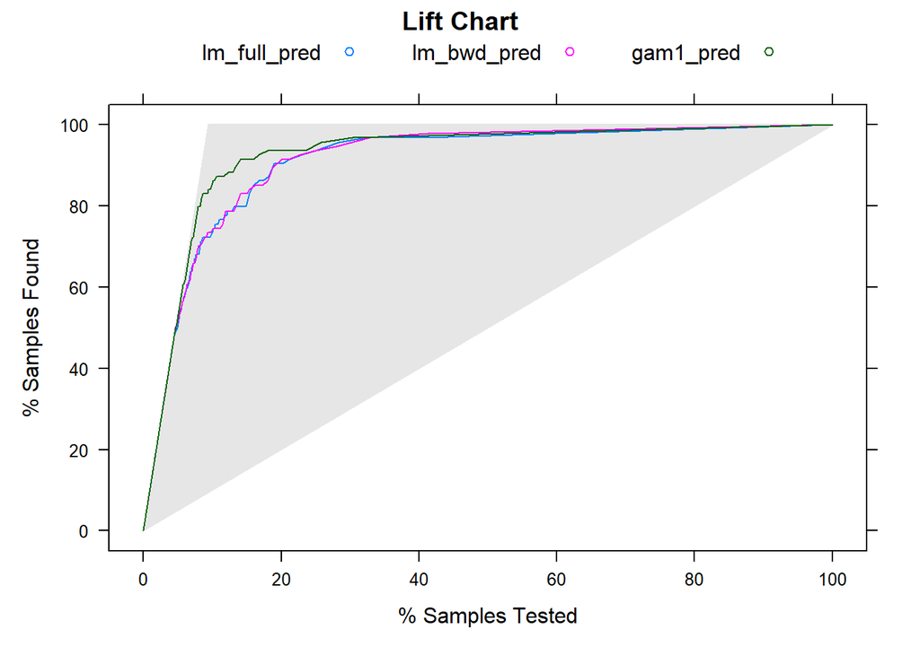

```r
lift_chart <- lift(test_data$Outcome~lm_full_pred+lm_bwd_pred+gam1_pred, class='Yes', cuts=100)
xyplot(lift_chart, auto.key=list(columns=3), main='Lift Chart')
```

## 4. Neural Networks

We now build an NN with all predictors, which allows both non-linearity and interaction among predictors. Note that the implementation of NN in R is **complicated** and significantly different from linear regression and GAM. It requires more manual configuration.

First of all, NN requires reformatted training data and test data. We first need to reformat the training data and construct a data frame with categorical predictors being represented as dummy variables and store it in `x_train_nn`. We then standardize all predictors $X$ in the data frame `x_train_nn` and combine the data frame with the dependent variable.

```r
# generate a data frame with categorical predictors being represented as dummy variables
x_train_nn <- model.matrix(~Age+Experience+Income+Family+CCAvg+Education+Mortgage+CD_Account+Online+CreditCard, data=train_data)[,-1]

# standardization
x_mean <- apply(x_train_nn, 2, mean)
x_sd <- apply(x_train_nn, 2, sd)
x_train_nn <- scale(x_train_nn, center=x_mean, scale=x_sd)

# combine with dependent variable Log_price
x_train_nn <- cbind.data.frame(train_data$Outcome, x_train_nn)
colnames(x_train_nn)[1] <- 'Outcome'
```

Second, we also need to reformat the test data. Note that when standardizing the test data, we use the mean and sd value retrieved from the **training data**. The reason is that the NN model will be estimated based on the training data that are standardized using the mean and sd value retrieved from the **training data**.

```r
# generate and standardize the data frame for the test data as well
x_test_nn <- model.matrix(~Age+Experience+Income+Family+CCAvg+Education+Mortgage+CD_Account+Online+CreditCard, data=test_data)[,-1]

# standardization
x_test_nn <- scale(x_test_nn, center=x_mean, scale=x_sd)
```

We now build an NN with all predictors available and store it in `nn1`. For the architecture of `nn1`, let’s have one hidden layer with 4 hidden units and keep the activation function as sigmoid. Note that there is randomness in the training of NN due to the random initialization of the optimization. Thus we use `set.seed()` to control the randomness and ensure reproducibility. We can use `plot()` function to visualize the estimated NN, however, it is difficult to interpret the estimated model.

```r
library(neuralnet)
```

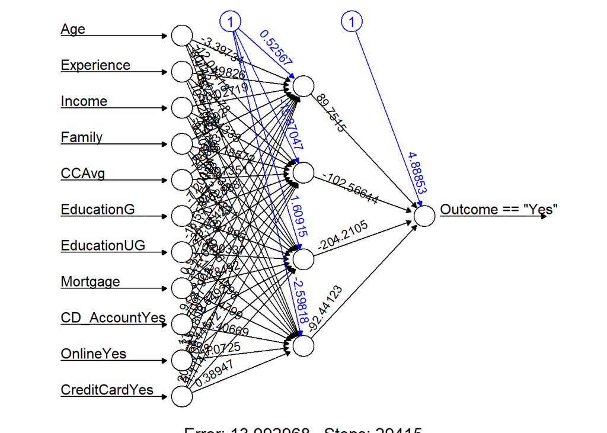

```r
set.seed(7)
nn1 <- neuralnet(Outcome=='Yes'~Age+Experience+Income+Family+CCAvg+EducationG+EducationUG+Mortgage+CD_AccountYes+OnlineYes+CreditCardYes, data=x_train_nn, hidden=c(4), linear.output=F)
plot(nn1, rep='best')
```

Let’s evaluate the out-of-sample prediction performance of `nn1`. Note that NN further improves the prediction accuracy, especially in terms of sensitivity.

```r
nn1_pred <- predict(nn1, newdata=x_test_nn)[,1]
nn1_acc <- confusionMatrix(factor(ifelse(nn1_pred>0.5, 'Yes', 'No')), test_data$Outcome, positive='Yes')
print(nn1_acc)
```

```
## Confusion Matrix and Statistics
##
##           Reference
## Prediction  No Yes
##        No  896  10
##        Yes  10  84
##
##                Accuracy : 0.98
##                  95% CI : (0.9693, 0.9877)
##     No Information Rate : 0.906
##     P-Value [Acc > NIR] : <2e-16
##
##                   Kappa : 0.8826
##
##  Mcnemar's Test P-Value : 1
##
##             Sensitivity : 0.8936
##             Specificity : 0.9890
##          Pos Pred Value : 0.8936
##          Neg Pred Value : 0.9890
##              Prevalence : 0.0940
##          Detection Rate : 0.0840
##    Detection Prevalence : 0.0940
##       Balanced Accuracy : 0.9413
##
##        'Positive' Class : Yes
##
```

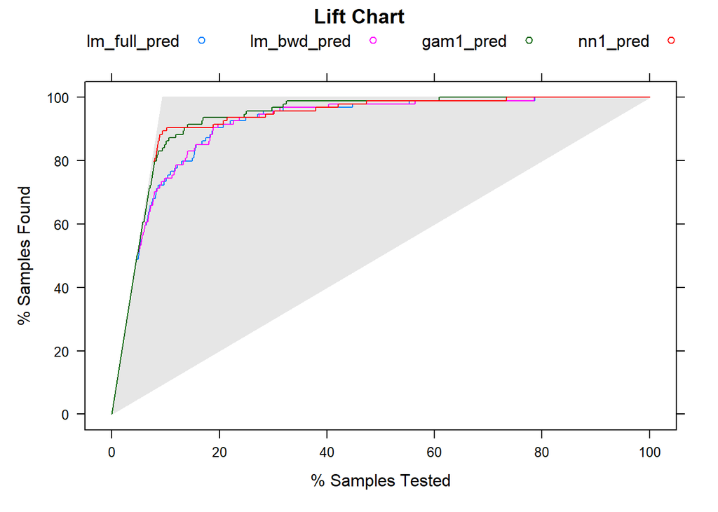

```r
lift_chart <- lift(test_data$Outcome~lm_full_pred+lm_bwd_pred+gam1_pred+nn1_pred, class='Yes')
xyplot(lift_chart, auto.key=list(columns=4), main='Lift Chart')
```

## 4. In-class Exercise (Optional)

Let’s read the confusion matrix of `nn1` and manually verify its accuracy, sensitivity and specificity.

```r
# TP <-
# FN <-
# TN <-
# FP <-

# accuracy <-
# sensitivity <-
# specificity <-

# print(c(accuracy, sensitivity, specificity))


TP <- 84
FN <- 10
TN <- 896
FP <- 10

accuracy <- 1 - (FN+FP)/(TP+FN+TN+FP)
sensitivity <- 1 - FN/(TP+FN)
specificity <- 1 - FP/(TN+FP)

print(c(accuracy, sensitivity, specificity))
```

```
## [1] 0.9800000 0.8936170 0.9889625
```

Let’s manually generate the lift chart for `gam1` and `nn1`.

```r
test_obs <- length(test_data$Outcome)
test_obs_yes <- sum(test_data$Outcome=='Yes')

ordered_outcome_nn <- test_data$Outcome[order(nn1_pred, decreasing=T)]=='Yes'
plot((1:test_obs)/test_obs, cumsum(ordered_outcome_nn)/test_obs_yes, type='l', col='red')

ordered_outcome_gam <- test_data$Outcome[order(gam1_pred, decreasing=T)]=='Yes'
lines((1:test_obs)/test_obs, cumsum(ordered_outcome_gam)/test_obs_yes, type='l', col='darkgreen')

ordered_outcome_lm <- test_data$Outcome[order(lm_full_pred, decreasing=T)]=='Yes'
lines((1:test_obs)/test_obs, cumsum(ordered_outcome_lm)/test_obs_yes, type='l', col='blue')

legend('bottomright', c('lm_full','gam1','nn1'), lty=1, col=c('blue','darkgreen','red'))
```

[output not shown]

We can also generate the ROC curves of each statistical model.

```r
## ROC curve
library(pROC)
plot(roc(test_data$Outcome, lm_full_pred), print.auc=T, col='blue', main='ROC Curves')
plot(roc(test_data$Outcome, gam1_pred), print.auc=T, col='green', print.auc.y=.4, add=TRUE)
plot(roc(test_data$Outcome, nn1_pred), print.auc=T, col='red', print.auc.y=.3, add=TRUE)
legend('bottomright', c('lm_full','gam1','nn1'), col=c('blue','green','red'), lty=1)
```

[output not shown]